# Árboles binomiales y opciones americanas: portafolio de ocho subyacentes

Eduardo Ayala Saldaña, Mariann Antonelli Morales Tobias y Ulises Salinas López

2026-10-24

## Integrantes

| Integrante | Matrícula |
| --- | --- |
| Eduardo Ayala Saldaña | A01192714 |
| Mariann Antonelli Morales Tobias | A01452078 |
| Ulises Salinas López | A00814787 |

## Objetivo y método

Se valúan con el modelo binomial de **Cox-Ross-Rubinstein (CRR)** ocho opciones **americanas**, una por cada subyacente del portafolio (SPY, TLT, XOM, GLD, SLV, NVDA, ASML y AMD), todas con vencimiento el **viernes 18 de diciembre de 2026**, es decir, a 56 días naturales de las cotizaciones (cerca de dos meses, dentro del rango de uno a tres que pide la actividad).

Para cada opción se hace lo siguiente:

1. Se construye el árbol y se **muestran los nodos de los primeros pasos**: precio del subyacente, valor intrínseco, valor de continuación y valor de la opción, marcando los nodos donde conviene ejercer antes.
2. Se compara la americana contra la europea del mismo árbol y contra Black-Scholes-Merton, para medir cuánto vale el derecho a ejercer antes del vencimiento.
3. Se obtienen las Griegas directamente de los nodos y se contrastan con las que publica TradingView.
4. Se lee del árbol la **distribución del precio a vencimiento** (forecast) y se calculan probabilidades de terminar en dinero y de ganar neto de prima.
5. Se justifica la estrategia (call o put) y se asigna el capital entre las ocho posiciones.

**Datos.** Las cotizaciones son capturas de **TradingView** del cierre del **viernes 23 de octubre de 2026** (bid, ask, volumen, volatilidad implícita, Griegas y precio teórico de cada contrato). El dividend yield de cada subyacente sale de la ficha del símbolo en TradingView. La ejecución se hizo en el simulador de Investopedia y sus capturas se anexan al final.

**Parámetros del modelo.**

- *Volatilidad:* la volatilidad implícita que publica TradingView para cada strike (una sola por strike, igual para el call y el put). Como control, también se despeja del propio árbol la volatilidad que reproduce el punto medio bid/ask.
- *Tasa libre de riesgo:* la misma de las tareas anteriores, 3.94 % continua (T-bill de 4 semanas, FRED).
- *Dividendos:* rendimiento continuo $q$ igual al *dividend yield (indicated)* de TradingView; es cero en GLD, SLV y AMD.
- *Plazo:* $T = 56/365$, con días naturales entre 365, igual que en el resto del curso.

**Limitaciones.** El open interest no aparece en las capturas, así que la liquidez se mide con el spread bid/ask y el volumen del día. Las tasas y los dividendos se suponen constantes. El dividend yield indicado es una aproximación del dividendo continuo; en ETF y acciones que pagan trimestral o mensual el dividendo real es discreto. Las probabilidades que salen del árbol son **neutrales al riesgo**, no pronósticos.

## Parámetros

```r
# 0. Limpiar la sesión

rm(list = ls())

# 1. Fechas y plazo

fecha_analisis    <- as.Date("2026-10-23")   # cierre de las cotizaciones
fecha_vencimiento <- as.Date("2026-12-18")   # tercer viernes de diciembre
dias_a_vencimiento <- as.numeric(fecha_vencimiento - fecha_analisis)   # 56 días
T_anios <- dias_a_vencimiento / 365

# 2. Tasa libre de riesgo (la misma de las tareas anteriores)

rf <- 0.0394

# 3. Otros parámetros

mult    <- 100       # acciones/ETF por contrato
capital <- 100000    # cuenta del simulador (USD)
N_precio <- 500      # pasos del árbol de valuación
N_nodos  <- 4        # pasos del árbol que se dibuja nodo por nodo
presupuesto_pos <- 3000   # prima objetivo por posición (USD); regla de asignación

cat("Plazo:", dias_a_vencimiento, "días; T =", round(T_anios, 5), "años\n")
```

```
## Plazo: 56 días; T = 0.15342 años
```

```r
cat("Tasa libre de riesgo (continua):", rf * 100, "%\n")
```

```
## Tasa libre de riesgo (continua): 3.94 %
```

```r
cat("Pasos de valuación:", N_precio, "-> cada paso dura", round(T_anios / N_precio * 365, 3), "días\n")
```

```
## Pasos de valuación: 500 -> cada paso dura 0.112 días
```

## Datos de mercado

```r
# Una fila por opción. Fuente: TradingView, cierre del 23-oct-2026, vto. 18-dic-2026.
# iv = volatilidad implícita de TradingView (%); d, g, rho, th, v = Griegas de TradingView
# (theta por día, vega por 1 punto de volatilidad, rho por 1 punto de tasa); teo = precio teórico.

op <- function(activo, tipo, K, S, q, bid, ask, vol, iv, d, g, rho, th, v, teo)
  data.frame(activo = activo, tipo = tipo, K = K, S = S, q = q, bid = bid, ask = ask,
             vol = vol, iv_tv = iv, delta_tv = d, gamma_tv = g, rho_tv = rho,
             theta_tv = th, vega_tv = v, teo_tv = teo, stringsAsFactors = FALSE)

mercado <- rbind(
  op("SPY",  "call",  759,   759.97, 0.0100, 21.28, 21.82,   50, 14.53,  0.53, 0.0092,  0.59, -0.16, 1.18,  18.29),
  op("SPY",  "put",   759,   759.97, 0.0100, 16.07, 16.24,   96, 14.53, -0.47, 0.0092, -0.57, -0.14, 1.18,  16.16),
  op("TLT",  "call",   81,    81.34, 0.0411,  1.78,  1.82,  721, 16.02,  0.55, 0.078,   0.065,-0.019, 0.13,   2.27),
  op("TLT",  "put",    81,    81.34, 0.0411,  1.79,  1.82,  648, 16.02, -0.45, 0.078,  -0.059,-0.017, 0.13,   1.80),
  op("XOM",  "call",  180,   183.21, 0.0225, 10.05, 10.40,  301, 30.57,  0.59, 0.018,   0.15, -0.079, 0.28,  10.50),
  op("XOM",  "put",   180,   183.21, 0.0225,  6.90,  7.35,  140, 30.57, -0.41, 0.018,  -0.13, -0.074, 0.28,   7.00),
  op("GLD",  "call",  366,   366.61, 0,       13.50, 13.80,   21, 20.63,  0.53, 0.013,   0.28, -0.11, 0.57,  12.40),
  op("GLD",  "put",   366,   366.61, 0,       11.00, 11.30,   41, 20.63, -0.47, 0.013,  -0.28, -0.10, 0.57,  11.20),
  op("SLV",  "call",   48,    48.72, 0,        3.30,  3.40,  518, 37.21,  0.57, 0.055,   0.038,-0.026, 0.075,  3.20),
  op("SLV",  "put",    48,    48.72, 0,        2.40,  2.49,  702, 37.21, -0.43, 0.055,  -0.036,-0.024, 0.075,  2.43),
  op("NVDA", "call",  210,   210.96, 0.0047, 14.20, 14.35, 1090, 39.24,  0.55, 0.012,   0.16, -0.12, 0.33,  13.50),
  op("NVDA", "put",   210,   210.96, 0.0047, 12.05, 12.25, 1440, 39.24, -0.45, 0.012,  -0.17, -0.11, 0.33,  12.25),
  op("ASML", "call", 1570,  1571.80, 0.0050, 102.90, 109.40,  16, 40.49,  0.54, 0.0016,  1.14, -0.91, 2.44, 101.20),
  op("ASML", "put",  1570,  1571.80, 0.0050,  93.00,  97.90,  12, 40.49, -0.46, 0.0016, -1.26, -0.86, 2.44,  97.00),
  op("AMD",  "call",  510,   516.79, 0,       49.65, 51.85,  535, 55.17,  0.57, 0.0035,  0.38, -0.40, 0.79,  48.00),
  op("AMD",  "put",   510,   516.79, 0,       40.10, 41.05,  312, 55.17, -0.43, 0.0035, -0.40, -0.38, 0.79,  40.40)
)

mercado$mid     <- (mercado$bid + mercado$ask) / 2
mercado$spread  <- (mercado$ask - mercado$bid) / mercado$mid * 100
mercado$id      <- paste(mercado$activo, mercado$tipo)

subyacentes <- data.frame(
  activo = c("SPY", "TLT", "XOM", "GLD", "SLV", "NVDA", "ASML", "AMD"),
  nombre = c("SPDR S&P 500 ETF", "iShares 20+ Year Treasury Bond ETF", "ExxonMobil",
             "SPDR Gold Shares", "iShares Silver Trust", "NVIDIA", "ASML (ADR de NY)",
             "Advanced Micro Devices"),
  clase  = c("ETF", "ETF", "Acción", "ETF", "ETF", "Acción", "Acción", "Acción"),
  stringsAsFactors = FALSE
)
subyacentes$spot <- mercado$S[match(subyacentes$activo, mercado$activo)]
subyacentes$q    <- mercado$q[match(subyacentes$activo, mercado$activo)]
subyacentes$iv   <- mercado$iv_tv[match(subyacentes$activo, mercado$activo)]
activos <- subyacentes$activo
```

```r
kable(data.frame(subyacentes$activo, subyacentes$nombre, subyacentes$clase,
                 subyacentes$spot, subyacentes$q * 100, subyacentes$iv),
      digits = c(0, 0, 0, 2, 2, 2), format.args = list(big.mark = ","),
      col.names = c("Activo", "Nombre", "Tipo", "Spot (USD)", "Dividend yield (%)",
                    "IV TradingView (%)"),
      caption = "Subyacentes del portafolio (cierre del 23-oct-2026)") %>%
  kable_styling(bootstrap_options = c("striped", "condensed"), full_width = FALSE)
```

Subyacentes del portafolio (cierre del 23-oct-2026)

| Activo | Nombre | Tipo | Spot (USD) | Dividend yield (%) | IV TradingView (%) |
| --- | --- | --- | --- | --- | --- |
| SPY | SPDR S&P 500 ETF | ETF | 759.97 | 1.00 | 14.53 |
| TLT | iShares 20+ Year Treasury Bond ETF | ETF | 81.34 | 4.11 | 16.02 |
| XOM | ExxonMobil | Acción | 183.21 | 2.25 | 30.57 |
| GLD | SPDR Gold Shares | ETF | 366.61 | 0.00 | 20.63 |
| SLV | iShares Silver Trust | ETF | 48.72 | 0.00 | 37.21 |
| NVDA | NVIDIA | Acción | 210.96 | 0.47 | 39.24 |
| ASML | ASML (ADR de NY) | Acción | 1,571.80 | 0.50 | 40.49 |
| AMD | Advanced Micro Devices | Acción | 516.79 | 0.00 | 55.17 |

```r
kable(data.frame(mercado$activo, mercado$tipo, mercado$K, mercado$bid, mercado$ask,
                 mercado$mid, mercado$spread, mercado$vol, mercado$teo_tv),
      digits = c(0, 0, 0, 2, 2, 3, 1, 0, 2), format.args = list(big.mark = ","),
      col.names = c("Activo", "Tipo", "Strike", "Bid", "Ask", "Punto medio",
                    "Spread (%)", "Volumen", "Precio teórico TV"),
      caption = "Las 16 opciones capturadas (call y put del strike más cercano al dinero)") %>%
  kable_styling(bootstrap_options = c("striped", "hover", "condensed"),
                full_width = FALSE, font_size = 12)
```

Las 16 opciones capturadas (call y put del strike más cercano al dinero)

| Activo | Tipo | Strike | Bid | Ask | Punto medio | Spread (%) | Volumen | Precio teórico TV |
| --- | --- | --- | --- | --- | --- | --- | --- | --- |
| SPY | call | 759 | 21.28 | 21.82 | 21.550 | 2.5 | 50 | 18.29 |
| SPY | put | 759 | 16.07 | 16.24 | 16.155 | 1.1 | 96 | 16.16 |
| TLT | call | 81 | 1.78 | 1.82 | 1.800 | 2.2 | 721 | 2.27 |
| TLT | put | 81 | 1.79 | 1.82 | 1.805 | 1.7 | 648 | 1.80 |
| XOM | call | 180 | 10.05 | 10.40 | 10.225 | 3.4 | 301 | 10.50 |
| XOM | put | 180 | 6.90 | 7.35 | 7.125 | 6.3 | 140 | 7.00 |
| GLD | call | 366 | 13.50 | 13.80 | 13.650 | 2.2 | 21 | 12.40 |
| GLD | put | 366 | 11.00 | 11.30 | 11.150 | 2.7 | 41 | 11.20 |
| SLV | call | 48 | 3.30 | 3.40 | 3.350 | 3.0 | 518 | 3.20 |
| SLV | put | 48 | 2.40 | 2.49 | 2.445 | 3.7 | 702 | 2.43 |
| NVDA | call | 210 | 14.20 | 14.35 | 14.275 | 1.1 | 1,090 | 13.50 |
| NVDA | put | 210 | 12.05 | 12.25 | 12.150 | 1.6 | 1,440 | 12.25 |
| ASML | call | 1,570 | 102.90 | 109.40 | 106.150 | 6.1 | 16 | 101.20 |
| ASML | put | 1,570 | 93.00 | 97.90 | 95.450 | 5.1 | 12 | 97.00 |
| AMD | call | 510 | 49.65 | 51.85 | 50.750 | 4.3 | 535 | 48.00 |
| AMD | put | 510 | 40.10 | 41.05 | 40.575 | 2.3 | 312 | 40.40 |

Se capturaron el call y el put de cada subyacente, en el strike más cercano al spot. La posición que se compra en cada activo es una de las dos; la otra sirve de contraste (paridad put-call y comparación del ejercicio anticipado entre calls y puts).

## El modelo CRR

En cada paso $\Delta t = T/N$ el precio sube por $u = e^{\sigma\sqrt{\Delta t}}$ o baja por $d = 1/u$, con probabilidad neutral al riesgo

$$p = \frac{e^{(r-q)\Delta t} - d}{u -
d}$$

El dividendo $q$ entra en la deriva neutral al riesgo: el subyacente rinde $r - q$ en promedio. Se valora hacia atrás. En la opción americana cada nodo toma el mayor entre ejercer ya y continuar:

$$f = \max\left( \text{ejercicio
inmediato},\; e^{-r\Delta t}\,[\,p\,f_{\uparrow} +
(1-p)\,f_{\downarrow}\,] \right)$$

## Funciones

```r
# Árbol CRR. Guarda los niveles 0..guardar con precio, continuación, valor y bandera de ejercicio.
# Nodo (i, k): i = paso, k = número de bajas; S = S0 * u^(i-k) * d^k

crr <- function(S0, K, r, q, sigma, T, N, tipo = "put", americana = TRUE, guardar = 2) {
  dt   <- T / N
  u    <- exp(sigma * sqrt(dt))
  d    <- 1 / u
  p    <- (exp((r - q) * dt) - d) / (u - d)
  stopifnot(p > 0, p < 1)
  disc <- exp(-r * dt)
  sg   <- if (tipo == "call") 1 else -1
  k    <- 0:N
  V    <- pmax(sg * (S0 * u^(N - k) * d^k - K), 0)      # pago al vencimiento
  niv  <- vector("list", guardar + 1); cont_l <- niv; ejer <- niv; intr_l <- niv
  if (N <= guardar) {
    niv[[N + 1]] <- V; intr_l[[N + 1]] <- V
    cont_l[[N + 1]] <- rep(NA_real_, N + 1); ejer[[N + 1]] <- rep(FALSE, N + 1)
  }
  if (N >= 1) for (i in (N - 1):0) {
    k    <- 0:i
    cont <- disc * (p * V[1:(i + 1)] + (1 - p) * V[2:(i + 2)])
    S_i  <- S0 * u^(i - k) * d^k
    intr <- pmax(sg * (S_i - K), 0)
    if (americana) {
      ej <- intr > cont + 1e-10
      V  <- pmax(cont, intr)
    } else {
      ej <- rep(FALSE, i + 1)
      V  <- cont
    }
    if (i <= guardar) {
      niv[[i + 1]] <- V; cont_l[[i + 1]] <- cont; ejer[[i + 1]] <- ej; intr_l[[i + 1]] <- intr
    }
  }
  list(precio = V[1], V = niv, cont = cont_l, intr = intr_l, ejer = ejer,
       u = u, d = d, p = p, dt = dt, N = N, S0 = S0)
}

# Griegas leídas del árbol (Hull, cap. 21). Theta por día, vega y rho por 1 punto.

griegas.arbol <- function(S0, K, r, q, sigma, T, N = 500, tipo = "put", americana = TRUE) {
  a  <- crr(S0, K, r, q, sigma, T, N, tipo, americana, guardar = 2)
  f0 <- a$V[[1]]; f1 <- a$V[[2]]; f2 <- a$V[[3]]
  u <- a$u; d <- a$d
  S11 <- S0 * u;    S10 <- S0 * d
  S22 <- S0 * u^2;  S21 <- S0;  S20 <- S0 * d^2
  delta <- (f1[1] - f1[2]) / (S11 - S10)
  gamma <- ((f2[1] - f2[2]) / (S22 - S21) - (f2[2] - f2[3]) / (S21 - S20)) /
           (0.5 * (S22 - S20))
  theta <- (f2[2] - f0) / (2 * a$dt) / 365
  vega  <- crr(S0, K, r, q, sigma + 0.01, T, N, tipo, americana)$precio - a$precio
  rho   <- crr(S0, K, r + 0.01, q, sigma, T, N, tipo, americana)$precio - a$precio
  c(delta = delta, gamma = gamma, theta = theta, vega = vega, rho = rho)
}

# Black-Scholes-Merton europeo con dividendo continuo

bs.precio <- function(S0, K, r, q, sigma, T, tipo = "put") {
  d1 <- (log(S0 / K) + (r - q + sigma^2 / 2) * T) / (sigma * sqrt(T))
  d2 <- d1 - sigma * sqrt(T)
  if (tipo == "call") S0 * exp(-q * T) * pnorm(d1) - K * exp(-r * T) * pnorm(d2)
  else K * exp(-r * T) * pnorm(-d2) - S0 * exp(-q * T) * pnorm(-d1)
}

bs.griegas <- function(S0, K, r, q, sigma, T, tipo = "put") {
  d1 <- (log(S0 / K) + (r - q + sigma^2 / 2) * T) / (sigma * sqrt(T))
  d2 <- d1 - sigma * sqrt(T)
  es_call <- tipo == "call"
  delta <- if (es_call) exp(-q * T) * pnorm(d1) else exp(-q * T) * (pnorm(d1) - 1)
  gamma <- exp(-q * T) * dnorm(d1) / (S0 * sigma * sqrt(T))
  vega  <- S0 * exp(-q * T) * dnorm(d1) * sqrt(T) / 100
  th_a  <- -S0 * exp(-q * T) * dnorm(d1) * sigma / (2 * sqrt(T)) +
    if (es_call) -r * K * exp(-r * T) * pnorm(d2) + q * S0 * exp(-q * T) * pnorm(d1)
    else          r * K * exp(-r * T) * pnorm(-d2) - q * S0 * exp(-q * T) * pnorm(-d1)
  rho <- (if (es_call) K * T * exp(-r * T) * pnorm(d2) else -K * T * exp(-r * T) * pnorm(-d2)) / 100
  c(delta = delta, gamma = gamma, theta = th_a / 365, vega = vega, rho = rho)
}

# Volatilidad implícita del ÁRBOL: la sigma con la que el árbol americano reproduce el precio

iv.arbol <- function(precio, S0, K, r, q, T, tipo, N = 200) {
  f <- function(s) crr(S0, K, r, q, s, T, N, tipo, TRUE, guardar = 0)$precio - precio
  res <- try(uniroot(f, interval = c(0.02, 3), tol = 1e-8), silent = TRUE)
  if (inherits(res, "try-error")) NA_real_ else res$root
}

# Distribución del precio a vencimiento que implica el árbol (binomial con p neutral)

distribucion.terminal <- function(S0, r, q, sigma, T, N = 500) {
  dt <- T / N; u <- exp(sigma * sqrt(dt)); d <- 1 / u
  p  <- (exp((r - q) * dt) - d) / (u - d)
  k  <- 0:N
  data.frame(S = S0 * u^(N - k) * d^k, prob = dbinom(k, N, 1 - p))
}

# Cuantil del precio en el día t: límite continuo del árbol (lognormal con deriva r - q),
# que evita el zigzag por la paridad de los pasos discretos

cuantil.arbol <- function(S0, r, q, sigma, i, alfa, N = 56, T = T_anios) {
  t <- i / N * T
  if (t == 0) return(S0)
  S0 * exp((r - q - sigma^2 / 2) * t + qnorm(alfa) * sigma * sqrt(t))
}

# Formatos

fmt <- function(x, d = 0) formatC(x, format = "f", digits = d, big.mark = ",")

# Inserción de capturas: si el archivo no está, avisa sin romper el knit

mostrar.imagenes <- function(archivos) {
  existen <- archivos[file.exists(archivos)]
  faltan  <- archivos[!file.exists(archivos)]
  if (length(faltan) > 0) {
    cat("Capturas no encontradas en la carpeta del .Rmd:\n")
    cat(paste("  -", faltan, collapse = "\n"), "\n")
  }
  if (length(existen) > 0) knitr::include_graphics(existen)
}
```

## Validación del código

Antes de usar datos reales, el árbol debe reproducir el ejemplo del libro (Hull, cap. 21): put americana con $S_0 = 50$, $K = 52$, $r = 5\%$, $\sigma = 30\%$, $T = 2$ años y $N = 2$ pasos.

```r
h_am <- crr(50, 52, 0.05, 0, 0.30, 2, 2, "put", TRUE,  guardar = 2)
h_eu <- crr(50, 52, 0.05, 0, 0.30, 2, 2, "put", FALSE, guardar = 2)

hull <- data.frame(
  Concepto = c("Put americana", "Put europea", "Prima de ejercicio anticipado",
               "Precio del nodo donde conviene ejercer (paso 1, baja)"),
  Valor = round(c(h_am$precio, h_eu$precio, h_am$precio - h_eu$precio, 50 * h_am$d), 4)
)
kable(hull, col.names = c("Concepto", "Valor")) %>%
  kable_styling(bootstrap_options = c("striped", "condensed"), full_width = FALSE)
```

| Concepto | Valor |
| --- | --- |
| Put americana | 7.4284 |
| Put europea | 6.2457 |
| Prima de ejercicio anticipado | 1.1827 |
| Precio del nodo donde conviene ejercer (paso 1, baja) | 37.0409 |

La put americana vale 7.4284, que coincide con el valor del libro (7.4284), y la europea 6.2457. La diferencia, 1.1827, es el valor de poder ejercer antes: en el nodo donde el precio cae a 37.04 al cabo de un año conviene cobrar el strike de inmediato.

Más pruebas (convergencia a Black-Scholes, paridad y Griegas) en el anexo.

## Resultados del árbol por opción

```r
calc <- do.call(rbind, lapply(seq_len(nrow(mercado)), function(i) {
  x <- mercado[i, ]
  s <- x$iv_tv / 100
  am <- crr(x$S, x$K, rf, x$q, s, T_anios, N_precio, x$tipo, TRUE)
  eu <- crr(x$S, x$K, rf, x$q, s, T_anios, N_precio, x$tipo, FALSE)
  a4 <- crr(x$S, x$K, rf, x$q, s, T_anios, N_nodos, x$tipo, TRUE, guardar = N_nodos)
  g  <- griegas.arbol(x$S, x$K, rf, x$q, s, T_anios, N_precio, x$tipo, TRUE)
  data.frame(id = x$id, activo = x$activo, tipo = x$tipo,
             p_am = am$precio, p_eu = eu$precio,
             p_bs = bs.precio(x$S, x$K, rf, x$q, s, T_anios, x$tipo),
             p_am4 = a4$precio, u = am$u, d = am$d, p = am$p,
             u4 = a4$u, d4 = a4$d, p4 = a4$p,
             iv_arbol = iv.arbol(x$mid, x$S, x$K, rf, x$q, T_anios, x$tipo) * 100,
             delta = g["delta"], gamma = g["gamma"], theta = g["theta"],
             vega = g["vega"], rho = g["rho"], row.names = NULL)
}))
calc$prima_ea  <- calc$p_am - calc$p_eu
calc$prima_pct <- calc$prima_ea / calc$p_am * 100
M <- cbind(mercado, calc[, setdiff(names(calc), c("id", "activo", "tipo"))])
rownames(M) <- M$id
```

```r
t1 <- data.frame(M$activo, M$tipo, M$iv_tv, M$iv_arbol, M$p_am, M$p_eu, M$p_bs,
                 M$prima_ea, M$mid, M$teo_tv)
kable(t1, digits = c(0, 0, 2, 2, 3, 3, 3, 4, 3, 2), row.names = FALSE,
      col.names = c("Activo", "Tipo", "IV TradingView (%)", "IV del árbol (%)",
                    "Americana (N=500)", "Europea (N=500)", "Black-Scholes",
                    "Prima ejercicio anticipado", "Punto medio mercado",
                    "Teórico TradingView"),
      caption = "Precios por acción con la IV de TradingView; IV del árbol = la que reproduce el punto medio") %>%
  kable_styling(bootstrap_options = c("striped", "hover", "condensed"),
                full_width = FALSE, font_size = 12)
```

Precios por acción con la IV de TradingView; IV del árbol = la que reproduce el punto medio

| Activo | Tipo | IV TradingView (%) | IV del árbol (%) | Americana (N=500) | Europea (N=500) | Black-Scholes | Prima ejercicio anticipado | Punto medio mercado | Teórico TradingView |
| --- | --- | --- | --- | --- | --- | --- | --- | --- | --- |
| SPY | call | 14.53 | 16.31 | 19.459 | 19.459 | 19.455 | 0.0000 | 21.550 | 18.29 |
| SPY | put | 14.53 | 15.23 | 15.335 | 15.080 | 15.076 | 0.2547 | 16.155 | 16.16 |
| TLT | call | 16.02 | 12.94 | 2.186 | 2.182 | 2.182 | 0.0035 | 1.800 | 2.27 |
| TLT | put | 16.02 | 15.52 | 1.866 | 1.865 | 1.865 | 0.0008 | 1.805 | 1.80 |
| XOM | call | 30.57 | 29.29 | 10.587 | 10.587 | 10.584 | 0.0000 | 10.225 | 10.50 |
| XOM | put | 30.57 | 31.24 | 6.951 | 6.924 | 6.921 | 0.0267 | 7.125 | 7.00 |
| GLD | call | 20.63 | 21.37 | 13.234 | 13.234 | 13.231 | 0.0000 | 13.650 | 12.40 |
| GLD | put | 20.63 | 21.64 | 10.579 | 10.418 | 10.416 | 0.1616 | 11.150 | 11.20 |
| SLV | call | 37.21 | 37.39 | 3.334 | 3.334 | 3.334 | 0.0000 | 3.350 | 3.20 |
| SLV | put | 37.21 | 38.55 | 2.342 | 2.325 | 2.325 | 0.0171 | 2.445 | 2.43 |
| NVDA | call | 39.24 | 40.33 | 13.918 | 13.918 | 13.913 | 0.0000 | 14.275 | 13.50 |
| NVDA | put | 39.24 | 39.95 | 11.919 | 11.845 | 11.840 | 0.0738 | 12.150 | 12.25 |
| ASML | call | 40.49 | 41.38 | 104.040 | 104.040 | 104.061 | 0.0000 | 106.150 | 101.20 |
| ASML | put | 40.49 | 40.88 | 94.554 | 93.984 | 94.004 | 0.5699 | 95.450 | 97.00 |
| AMD | call | 55.17 | 57.13 | 49.164 | 49.164 | 49.148 | 0.0000 | 50.750 | 48.00 |
| AMD | put | 55.17 | 56.49 | 39.489 | 39.300 | 39.284 | 0.1891 | 40.575 | 40.40 |

```r
t2 <- data.frame(M$id, M$iv_tv, M$q * 100, M$u4, M$d4, M$p4, M$u, M$d, M$p, M$p_am4, M$p_am)
kable(t2, digits = c(0, 2, 2, 4, 4, 4, 5, 5, 5, 3, 3), row.names = FALSE,
      col.names = c("Opción", "σ (%)", "q (%)", "u (N=4)", "d (N=4)", "p (N=4)",
                    "u (N=500)", "d (N=500)", "p (N=500)",
                    "Precio N=4", "Precio N=500"),
      caption = "Parámetros del árbol: el de 4 pasos se dibuja, el de 500 valúa") %>%
  kable_styling(bootstrap_options = c("striped", "hover", "condensed"),
                full_width = FALSE, font_size = 12)
```

Parámetros del árbol: el de 4 pasos se dibuja, el de 500 valúa

| Opción | σ (%) | q (%) | u (N=4) | d (N=4) | p (N=4) | u (N=500) | d (N=500) | p (N=500) | Precio N=4 | Precio N=500 |
| --- | --- | --- | --- | --- | --- | --- | --- | --- | --- | --- |
| SPY call | 14.53 | 1.00 | 1.0289 | 0.9719 | 0.5127 | 1.00255 | 0.99746 | 0.50114 | 18.595 | 19.459 |
| SPY put | 14.53 | 1.00 | 1.0289 | 0.9719 | 0.5127 | 1.00255 | 0.99746 | 0.50114 | 14.657 | 15.335 |
| TLT call | 16.02 | 4.11 | 1.0319 | 0.9691 | 0.4911 | 1.00281 | 0.99720 | 0.49921 | 2.128 | 2.186 |
| TLT put | 16.02 | 4.11 | 1.0319 | 0.9691 | 0.4911 | 1.00281 | 0.99720 | 0.49921 | 1.803 | 1.866 |
| XOM call | 30.57 | 2.25 | 1.0617 | 0.9419 | 0.4904 | 1.00537 | 0.99466 | 0.49915 | 10.569 | 10.587 |
| XOM put | 30.57 | 2.25 | 1.0617 | 0.9419 | 0.4904 | 1.00537 | 0.99466 | 0.49915 | 6.924 | 6.951 |
| GLD call | 20.63 | 0.00 | 1.0412 | 0.9604 | 0.5086 | 1.00362 | 0.99639 | 0.50077 | 12.633 | 13.234 |
| GLD put | 20.63 | 0.00 | 1.0412 | 0.9604 | 0.5086 | 1.00362 | 0.99639 | 0.50077 | 10.105 | 10.579 |
| SLV call | 37.21 | 0.00 | 1.0756 | 0.9297 | 0.4922 | 1.00654 | 0.99350 | 0.49930 | 3.285 | 3.334 |
| SLV put | 37.21 | 0.00 | 1.0756 | 0.9297 | 0.4922 | 1.00654 | 0.99350 | 0.49930 | 2.285 | 2.342 |
| NVDA call | 39.24 | 0.47 | 1.0799 | 0.9260 | 0.4895 | 1.00690 | 0.99315 | 0.49906 | 13.314 | 13.918 |
| NVDA put | 39.24 | 0.47 | 1.0799 | 0.9260 | 0.4895 | 1.00690 | 0.99315 | 0.49906 | 11.329 | 11.919 |
| ASML call | 40.49 | 0.50 | 1.0825 | 0.9238 | 0.4885 | 1.00712 | 0.99293 | 0.49897 | 98.450 | 104.040 |
| ASML put | 40.49 | 0.50 | 1.0825 | 0.9238 | 0.4885 | 1.00712 | 0.99293 | 0.49897 | 89.692 | 94.554 |
| AMD call | 55.17 | 0.00 | 1.1141 | 0.8976 | 0.4800 | 1.00971 | 0.99038 | 0.49821 | 47.679 | 49.164 |
| AMD put | 55.17 | 0.00 | 1.1141 | 0.8976 | 0.4800 | 1.00971 | 0.99038 | 0.49821 | 37.923 | 39.489 |

## Estrategias y asignación del portafolio

### Posiciones propuestas

```r
# Una posición por subyacente. Todas son compras de opciones (pérdida máxima = prima pagada).
# contratos_manual permite fijar la cantidad a mano; con NA se aplica la regla
# "prima objetivo por posición": contratos = max(1, round(presupuesto / costo de un contrato)).

pos <- data.frame(
  activo = activos,
  tipo   = c("put", "call", "call", "call", "put", "call", "call", "put"),
  contratos_manual = c(NA, NA, NA, NA, NA, NA, NA, NA),
  stringsAsFactors = FALSE
)
pos$id <- paste(pos$activo, pos$tipo)
Mp <- M[pos$id, ]
pos$K <- Mp$K; pos$S <- Mp$S; pos$q <- Mp$q; pos$bid <- Mp$bid; pos$ask <- Mp$ask
pos$iv <- Mp$iv_tv
pos$contratos <- ifelse(is.na(pos$contratos_manual),
                        pmax(1, round(presupuesto_pos / (pos$ask * mult))),
                        pos$contratos_manual)
pos$cantidad <- pos$contratos * mult
pos$costo    <- pos$cantidad * pos$ask
pos$pct_cap  <- pos$costo / capital * 100
pos$equilibrio <- ifelse(pos$tipo == "call", pos$K + pos$ask, pos$K - pos$ask)
pos$mov_req    <- (pos$equilibrio / pos$S - 1) * 100
pos$costo_ejec <- pos$cantidad * (pos$ask - pos$bid) / 2
rownames(pos) <- pos$activo
```

```r
tp <- data.frame(
  Activo = pos$activo,
  Posicion = paste("Compra", pos$tipo, pos$K),
  Vencimiento = format(fecha_vencimiento, "%d-%b-%Y"),
  Contratos = pos$contratos,
  Prima = pos$ask,
  Costo = pos$costo,
  Pct = pos$pct_cap,
  Equilibrio = pos$equilibrio,
  Mov = pos$mov_req,
  Spread = Mp$spread,
  Volumen = Mp$vol
)
tp <- rbind(tp, data.frame(Activo = "Total", Posicion = "", Vencimiento = "",
                           Contratos = sum(pos$contratos), Prima = NA,
                           Costo = sum(pos$costo), Pct = sum(pos$pct_cap),
                           Equilibrio = NA, Mov = NA, Spread = NA, Volumen = NA))
kable(tp, digits = c(0, 0, 0, 0, 2, 0, 1, 2, 2, 1, 0), row.names = FALSE,
      format.args = list(big.mark = ","),
      col.names = c("Activo", "Posición", "Vencimiento", "Contratos",
                    "Prima de entrada (ask)", "Costo (USD)", "% del capital",
                    "Equilibrio", "Movimiento requerido (%)", "Spread (%)", "Volumen"),
      caption = "Tabla de operaciones: entrada al ask, cuenta de 100,000 USD") %>%
  kable_styling(bootstrap_options = c("striped", "hover", "condensed"),
                full_width = FALSE, font_size = 12) %>%
  row_spec(nrow(tp), bold = TRUE)
```

Tabla de operaciones: entrada al ask, cuenta de 100,000 USD

| Activo | Posición | Vencimiento | Contratos | Prima de entrada (ask) | Costo (USD) | % del capital | Equilibrio | Movimiento requerido (%) | Spread (%) | Volumen |
| --- | --- | --- | --- | --- | --- | --- | --- | --- | --- | --- |
| SPY | Compra put 759 | 18-Dec-2026 | 2 | 16.24 | 3,248 | 3.2 | 742.76 | -2.26 | 1.1 | 96 |
| TLT | Compra call 81 | 18-Dec-2026 | 16 | 1.82 | 2,912 | 2.9 | 82.82 | 1.82 | 2.2 | 721 |
| XOM | Compra call 180 | 18-Dec-2026 | 3 | 10.40 | 3,120 | 3.1 | 190.40 | 3.92 | 3.4 | 301 |
| GLD | Compra call 366 | 18-Dec-2026 | 2 | 13.80 | 2,760 | 2.8 | 379.80 | 3.60 | 2.2 | 21 |
| SLV | Compra put 48 | 18-Dec-2026 | 12 | 2.49 | 2,988 | 3.0 | 45.51 | -6.59 | 3.7 | 702 |
| NVDA | Compra call 210 | 18-Dec-2026 | 2 | 14.35 | 2,870 | 2.9 | 224.35 | 6.35 | 1.1 | 1,090 |
| ASML | Compra call 1570 | 18-Dec-2026 | 1 | 109.40 | 10,940 | 10.9 | 1,679.40 | 6.85 | 6.1 | 16 |
| AMD | Compra put 510 | 18-Dec-2026 | 1 | 41.05 | 4,105 | 4.1 | 468.95 | -9.26 | 2.3 | 312 |
| Total |  |  | 39 | NA | 32,943 | 32.9 | NA | NA | NA | NA |

La dirección de cada posición responde al papel que cumple en el conjunto:

Lógica de cada posición (las fechas de reporte salen de la ficha de TradingView del 24-oct-2026)

| Activo | Posición | Papel en el portafolio |
| --- | --- | --- |
| SPY | Put 759 | Cobertura del mercado amplio. Es el subyacente de menor volatilidad del lote (IV de 14.5 %), así que la protección es la más barata en relación con el nocional de 76,000 USD por contrato. |
| TLT | Call 81 | Bonos largos con dividendo mensual alto (4.11 %). Con $q$ mayor que $r$ es donde un call americano puede tener prima de ejercicio anticipado positiva. |
| XOM | Call 180 | Energía. Dividendo de 2.25 % y reporte de resultados a 6 días: el call incluye ese evento dentro de su vida. Subió 2.79 % en la sesión. |
| GLD | Call 366 | Oro, sin dividendo. Sirve de referencia: un call sin dividendo debe tener prima de ejercicio anticipado cero. |
| SLV | Put 48 | Plata, sin dividendo. Una put sin dividendo es el caso donde el ejercicio anticipado depende solo de la tasa de interés. |
| NVDA | Call 210 | Semiconductores de gran capitalización y la cadena más líquida de las tres acciones (1,090 y 1,440 contratos). Reporta en 32 días, dentro del vencimiento. |
| ASML | Call 1570 | Cuello de botella de la cadena de semiconductores. Ya reportó el 13 de octubre; es la opción menos líquida del portafolio. |
| AMD | Put 510 | Contrapeso bajista y la volatilidad implícita más alta del lote (55.2 %). Es una put fuera del dinero, así que toda su prima es valor temporal. Reporta en 10 días, dentro de la vida de la opción. |

El portafolio queda con cinco calls (TLT, XOM, GLD, NVDA y ASML) y tres puts (SPY, SLV y AMD). Las cinco calls apuestan a que el precio suba por encima del equilibrio; las tres puts compensan en la cola bajista. No se vende ninguna opción, de modo que **la pérdida máxima es exactamente la prima pagada**.

```r
G <- data.frame(
  Activo = pos$activo,
  delta_usd = pos$cantidad * Mp$delta * pos$S,
  gamma_usd = pos$cantidad * Mp$gamma * pos$S^2 * 0.01,
  vega_usd  = pos$cantidad * Mp$vega,
  theta_usd = pos$cantidad * Mp$theta,
  rho_usd   = pos$cantidad * Mp$rho
)
Gt <- rbind(G, data.frame(Activo = "Portafolio", t(colSums(G[, -1]))))
kable(Gt, digits = c(0, 0, 0, 1, 1, 1), row.names = FALSE,
      format.args = list(big.mark = ","),
      col.names = c("Posición", "Delta (USD)", "Gamma (USD por 1 %)",
                    "Vega (USD por 1 pto)", "Theta (USD por día)", "Rho (USD por 1 pto)"),
      caption = "Griegas del árbol en dólares (cantidad = contratos x 100)") %>%
  kable_styling(bootstrap_options = c("striped", "hover", "condensed"),
                full_width = FALSE, font_size = 12) %>%
  row_spec(nrow(Gt), bold = TRUE)
```

Griegas del árbol en dólares (cantidad = contratos x 100)

| Posición | Delta (USD) | Gamma (USD por 1 %) | Vega (USD por 1 pto) | Theta (USD por día) | Rho (USD por 1 pto) |
| --- | --- | --- | --- | --- | --- |
| SPY | -69,591 | 10,967 | 234.8 | -25.8 | -86.3 |
| TLT | 69,671 | 8,232 | 201.7 | -28.2 | 96.6 |
| XOM | 32,351 | 1,779 | 83.6 | -23.9 | 44.9 |
| GLD | 40,619 | 3,590 | 113.5 | -25.0 | 58.6 |
| SLV | -24,462 | 1,590 | 89.0 | -27.2 | -34.8 |
| NVDA | 23,447 | 1,084 | 65.2 | -24.8 | 31.8 |
| ASML | 86,016 | 3,927 | 243.5 | -95.2 | 116.4 |
| AMD | -21,943 | 947 | 79.3 | -36.7 | -33.4 |
| Portafolio | 136,107 | 32,115 | 1,110.7 | -286.8 | 193.8 |

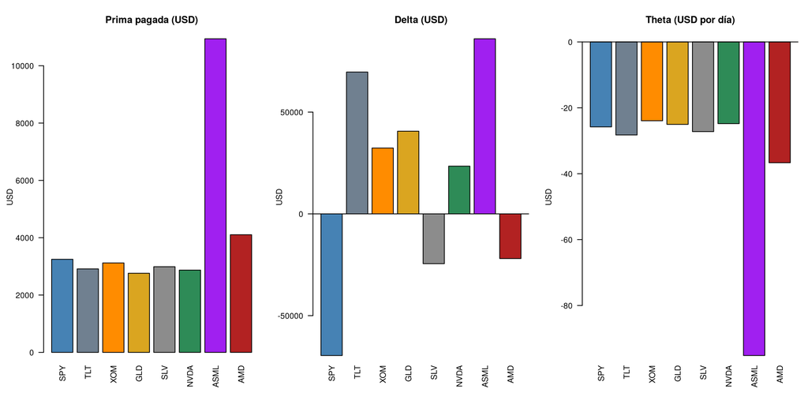

```r
colores <- c(SPY = "steelblue", TLT = "slategray", XOM = "darkorange", GLD = "goldenrod",
             SLV = "gray55", NVDA = "seagreen", ASML = "purple", AMD = "firebrick")
par(mfrow = c(1, 3), mar = c(5, 4.5, 4, 1))
barplot(pos$costo, names.arg = pos$activo, col = colores[pos$activo],
        main = "Prima pagada (USD)", ylab = "USD", las = 2)
barplot(G$delta_usd, names.arg = G$Activo, col = colores[G$Activo],
        main = "Delta (USD)", ylab = "USD", las = 2); abline(h = 0)
barplot(G$theta_usd, names.arg = G$Activo, col = colores[G$Activo],
        main = "Theta (USD por día)", ylab = "USD", las = 2); abline(h = 0)
```

```r
par(mfrow = c(1, 1))
```

```r
riesgo <- data.frame(
  Concepto = c("Capital de la cuenta", "Prima total pagada = pérdida máxima",
               "Pérdida máxima / capital", "Delta del portafolio / capital",
               "Costo de ejecución de entrada (medio spread)",
               "Costo de ejecución atribuible a ASML", "Theta del portafolio por día"),
  Valor = c(paste0(fmt(capital), " USD"), paste0(fmt(sum(pos$costo)), " USD"),
            paste0(round(sum(pos$costo) / capital * 100, 1), " %"),
            paste0(round(sum(G$delta_usd) / capital * 100), " %"),
            paste0(fmt(sum(pos$costo_ejec)), " USD"),
            paste0(fmt(pos["ASML", "costo_ejec"]), " USD (",
                   round(pos["ASML", "costo_ejec"] / sum(pos$costo_ejec) * 100), " %)"),
            paste0(fmt(sum(G$theta_usd), 1), " USD"))
)
kable(riesgo, align = c("l", "r"),
      caption = "Al ser todas las posiciones compras, la prima pagada es el riesgo total") %>%
  kable_styling(bootstrap_options = c("striped", "condensed"), full_width = FALSE)
```

Al ser todas las posiciones compras, la prima pagada es el riesgo total

| Concepto | Valor |
| --- | --- |
| Capital de la cuenta | 100,000 USD |
| Prima total pagada = pérdida máxima | 32,943 USD |
| Pérdida máxima / capital | 32.9 % |
| Delta del portafolio / capital | 136 % |
| Costo de ejecución de entrada (medio spread) | 573 USD |
| Costo de ejecución atribuible a ASML | 325 USD (57 %) |
| Theta del portafolio por día | -286.8 USD |

## Árboles binomiales por subyacente

```r
dibuja.arbol <- function(id, titulo) {
  x <- M[id, ]
  a <- crr(x$S, x$K, rf, x$q, x$iv_tv / 100, T_anios, N_nodos, x$tipo, TRUE, guardar = N_nodos)
  N <- a$N
  dec <- if (x$S < 100) 2 else 1
  par(mar = c(3, 1, 3.5, 1))
  plot(NULL, xlim = c(-0.35, N + 0.45), ylim = c(-N - 0.7, N + 0.7), axes = FALSE,
       xlab = "", ylab = "", main = titulo)
  for (i in 0:(N - 1)) for (k in 0:i) {
    y <- i - 2 * k
    segments(i, y, i + 1, y + 1, col = "gray75"); segments(i, y, i + 1, y - 1, col = "gray75")
  }
  for (i in 0:N) for (k in 0:i) {
    y  <- i - 2 * k
    S  <- x$S * a$u^(i - k) * a$d^k
    v  <- a$V[[i + 1]][k + 1]
    ej <- a$ejer[[i + 1]][k + 1]
    if (ej) rect(i - 0.36, y - 0.52, i + 0.36, y + 0.52, border = "firebrick", lwd = 1.5)
    text(i, y + 0.2, formatC(S, format = "f", digits = dec, big.mark = ","), cex = 0.78)
    text(i, y - 0.25, formatC(v, format = "f", digits = 2), cex = 0.78,
         col = ifelse(ej, "firebrick", "darkgreen"), font = ifelse(ej, 2, 1))
  }
  axis(1, at = 0:N, labels = paste0("Paso ", 0:N, "\n(día ", round(0:N * T_anios / N * 365), ")"),
       tick = FALSE, cex.axis = 0.85)
  legend("topleft", bty = "n", cex = 0.8, text.col = c("black", "darkgreen", "firebrick"),
         legend = c("Arriba: precio del subyacente", "Abajo: valor de la opción",
                    "Rojo con marco: ejercer ya"))
}

tabla.nodos <- function(id) {
  x <- M[id, ]
  a <- crr(x$S, x$K, rf, x$q, x$iv_tv / 100, T_anios, N_nodos, x$tipo, TRUE, guardar = N_nodos)
  filas <- list()
  for (i in 0:N_nodos) for (k in 0:i) {
    filas[[length(filas) + 1]] <- data.frame(
      Paso = i, Bajas = k, S = x$S * a$u^(i - k) * a$d^k,
      Intrinseco = a$intr[[i + 1]][k + 1], Continuacion = a$cont[[i + 1]][k + 1],
      Valor = a$V[[i + 1]][k + 1],
      Decision = if (i == N_nodos) "Vencimiento" else if (a$ejer[[i + 1]][k + 1]) "EJERCER" else "Continuar")
  }
  d <- do.call(rbind, filas)
  d <- d[d$Paso <= 3 | d$Decision == "EJERCER", ]
  kable(d, digits = c(0, 0, 2, 3, 3, 3, 0), row.names = FALSE,
        format.args = list(big.mark = ","),
        col.names = c("Paso", "Nº de bajas", "Precio S", "Valor intrínseco",
                      "Valor de continuación", "Valor de la opción", "Decisión"),
        caption = paste0("Nodos de los pasos 0 a 3 (y cualquier nodo de ejercicio): ", id)) %>%
    kable_styling(bootstrap_options = c("striped", "hover", "condensed"),
                  full_width = FALSE, font_size = 11) %>%
    row_spec(which(d$Decision == "EJERCER"), bold = TRUE, color = "firebrick")
}

tabla.opcion <- function(a) {
  filas <- M[M$activo == a, ]
  d <- data.frame(
    Opcion = filas$id, Bid = filas$bid, Ask = filas$ask, Mid = filas$mid,
    ArbolAm = filas$p_am, ArbolEu = filas$p_eu, Prima = filas$prima_ea,
    Delta = filas$delta, DeltaTV = filas$delta_tv,
    Gamma = filas$gamma, GammaTV = filas$gamma_tv,
    Theta = filas$theta, ThetaTV = filas$theta_tv,
    Vega = filas$vega, VegaTV = filas$vega_tv,
    Rho = filas$rho, RhoTV = filas$rho_tv)
  kable(d, digits = c(0, 2, 2, 3, 3, 3, 4, 3, 2, 4, 4, 3, 3, 3, 3, 3, 3), row.names = FALSE,
        col.names = c("Opción", "Bid", "Ask", "Mid", "Árbol am.", "Árbol eur.",
                      "Prima EA", "Delta", "Delta TV", "Gamma", "Gamma TV",
                      "Theta", "Theta TV", "Vega", "Vega TV", "Rho", "Rho TV"),
        caption = "Precios por acción y Griegas: árbol (N=500) contra TradingView") %>%
    kable_styling(bootstrap_options = c("striped", "hover", "condensed"),
                  full_width = FALSE, font_size = 11)
}

# Texto de conclusión generado con los resultados, para que no se desfase del código

conclusion <- function(a) {
  p  <- pos[a, ]; x <- M[p$id, ]
  dist <- distribucion.terminal(x$S, rf, x$q, x$iv_tv / 100, T_anios, N_precio)
  pago <- if (x$tipo == "call") pmax(dist$S - x$K, 0) else pmax(x$K - dist$S, 0)
  p_itm <- sum(dist$prob[pago > 0]) * 100
  p_gan <- sum(dist$prob[pago > x$ask]) * 100
  dif   <- (x$mid / x$p_am - 1) * 100
  ea <- if (x$tipo == "call" && x$q == 0) {
    "Como no paga dividendo, ejercer un call antes del vencimiento nunca conviene y la americana vale exactamente lo mismo que la europea."
  } else if (x$prima_pct < 0.5) {
    sprintf("La prima de ejercicio anticipado es de %s USD por acción (%s %% del valor): a 56 días es económicamente despreciable.",
            formatC(x$prima_ea, format = "f", digits = 4), formatC(x$prima_pct, format = "f", digits = 2))
  } else {
    sprintf("La prima de ejercicio anticipado es de %s USD por acción (%s %% del valor): pequeña, pero positiva y medible.",
            formatC(x$prima_ea, format = "f", digits = 3), formatC(x$prima_pct, format = "f", digits = 2))
  }
  sprintf(paste0("Con %d contrato(s) la prima pagada al ask es de %s USD (%s %% del capital). ",
                 "El equilibrio al vencimiento está en %s, un %s %% %s del spot. ",
                 "El árbol, con la IV de TradingView (%s %%), valúa la opción en %s por acción contra un punto medio de mercado de %s (el mercado cotiza %s %% %s que el modelo). %s ",
                 "Bajo la medida neutral al riesgo, la probabilidad de terminar en dinero es de %s %% y la de ganar neto de prima, de %s %%."),
          p$contratos, fmt(p$costo), formatC(p$pct_cap, format = "f", digits = 1),
          fmt(p$equilibrio, 2), formatC(abs(p$mov_req), format = "f", digits = 1),
          ifelse(p$mov_req >= 0, "arriba", "abajo"),
          formatC(x$iv_tv, format = "f", digits = 2), formatC(x$p_am, format = "f", digits = 3),
          formatC(x$mid, format = "f", digits = 3), formatC(abs(dif), format = "f", digits = 1),
          ifelse(dif >= 0, "más caro", "más barato"), ea,
          formatC(p_itm, format = "f", digits = 0), formatC(p_gan, format = "f", digits = 0))
}
```

### SPY: put 759 (cobertura)

Compra de puts con strike 759, el más cercano al spot de 759.97. Es la cobertura del portafolio.

```r
tabla.opcion("SPY")
```

Precios por acción y Griegas: árbol (N=500) contra TradingView

| Opción | Bid | Ask | Mid | Árbol am. | Árbol eur. | Prima EA | Delta | Delta TV | Gamma | Gamma TV | Theta | Theta TV | Vega | Vega TV | Rho | Rho TV |
| --- | --- | --- | --- | --- | --- | --- | --- | --- | --- | --- | --- | --- | --- | --- | --- | --- |
| SPY call | 21.28 | 21.82 | 21.550 | 19.459 | 19.459 | 0.0000 | 0.551 | 0.53 | 0.0091 | 0.0092 | -0.184 | -0.16 | 1.176 | 1.18 | 0.618 | 0.59 |
| SPY put | 16.07 | 16.24 | 16.155 | 15.335 | 15.080 | 0.2547 | -0.458 | -0.47 | 0.0095 | 0.0092 | -0.129 | -0.14 | 1.174 | 1.18 | -0.432 | -0.57 |

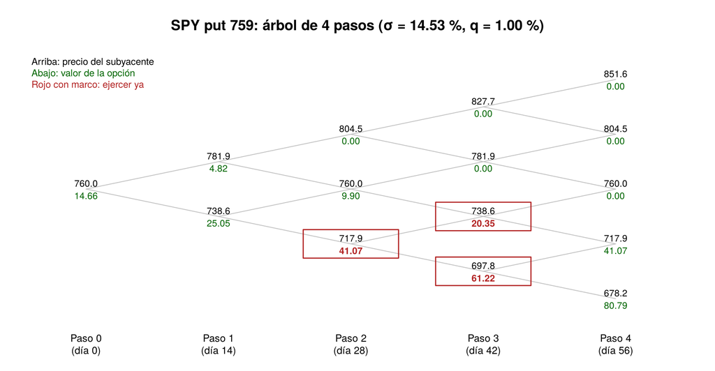

```r
dibuja.arbol("SPY put", "SPY put 759: árbol de 4 pasos (σ = 14.53 %, q = 1.00 %)")
```

```r
tabla.nodos("SPY put")
```

Nodos de los pasos 0 a 3 (y cualquier nodo de ejercicio): SPY put

| Paso | Nº de bajas | Precio S | Valor intrínseco | Valor de continuación | Valor de la opción | Decisión |
| --- | --- | --- | --- | --- | --- | --- |
| 0 | 0 | 759.97 | 0.000 | 14.657 | 14.657 | Continuar |
| 1 | 0 | 781.91 | 0.000 | 4.818 | 4.818 | Continuar |
| 1 | 1 | 738.65 | 20.351 | 25.054 | 25.054 | Continuar |
| 2 | 0 | 804.48 | 0.000 | 0.000 | 0.000 | Continuar |
| 2 | 1 | 759.97 | 0.000 | 9.902 | 9.902 | Continuar |
| 2 | 2 | 717.93 | 41.075 | 40.204 | 41.075 | EJERCER |
| 3 | 0 | 827.70 | 0.000 | 0.000 | 0.000 | Continuar |
| 3 | 1 | 781.91 | 0.000 | 0.000 | 0.000 | Continuar |
| 3 | 2 | 738.65 | 20.351 | 19.985 | 20.351 | EJERCER |
| 3 | 3 | 697.78 | 61.216 | 60.338 | 61.216 | EJERCER |

**Conclusión.** Con 2 contrato(s) la prima pagada al ask es de 3,248 USD (3.2 % del capital). El equilibrio al vencimiento está en 742.76, un 2.3 % abajo del spot. El árbol, con la IV de TradingView (14.53 %), valúa la opción en 15.335 por acción contra un punto medio de mercado de 16.155 (el mercado cotiza 5.3 % más caro que el modelo). La prima de ejercicio anticipado es de 0.255 USD por acción (1.66 % del valor): pequeña, pero positiva y medible. Bajo la medida neutral al riesgo, la probabilidad de terminar en dinero es de 46 % y la de ganar neto de prima, de 33 %. En el árbol de 4 pasos el ejercicio anticipado aparece solo en los nodos con varias bajas seguidas, cuando el precio queda muy por debajo del strike y la tasa de 3.94 % hace más valioso cobrar el strike hoy que esperar.

### TLT: call 81

Compra de calls con strike 81, el más cercano al spot de 81.34. TLT paga un dividendo alto, de 4.11 % indicado, y es el caso donde el dividendo pesa más que la tasa.

```r
tabla.opcion("TLT")
```

Precios por acción y Griegas: árbol (N=500) contra TradingView

| Opción | Bid | Ask | Mid | Árbol am. | Árbol eur. | Prima EA | Delta | Delta TV | Gamma | Gamma TV | Theta | Theta TV | Vega | Vega TV | Rho | Rho TV |
| --- | --- | --- | --- | --- | --- | --- | --- | --- | --- | --- | --- | --- | --- | --- | --- | --- |
| TLT call | 1.78 | 1.82 | 1.800 | 2.186 | 2.182 | 0.0035 | 0.535 | 0.55 | 0.0778 | 0.078 | -0.018 | -0.019 | 0.126 | 0.13 | 0.060 | 0.065 |
| TLT put | 1.79 | 1.82 | 1.805 | 1.866 | 1.865 | 0.0008 | -0.460 | -0.45 | 0.0775 | 0.078 | -0.018 | -0.017 | 0.126 | 0.13 | -0.053 | -0.059 |

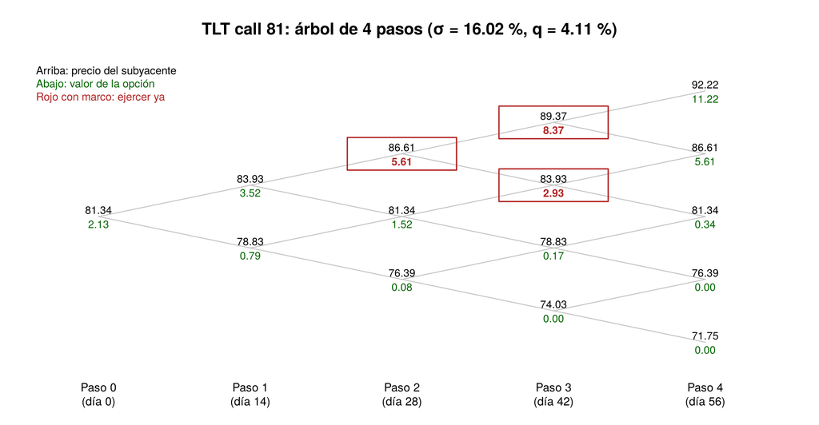

```r
dibuja.arbol("TLT call", "TLT call 81: árbol de 4 pasos (σ = 16.02 %, q = 4.11 %)")
```

```r
tabla.nodos("TLT call")
```

Nodos de los pasos 0 a 3 (y cualquier nodo de ejercicio): TLT call

| Paso | Nº de bajas | Precio S | Valor intrínseco | Valor de continuación | Valor de la opción | Decisión |
| --- | --- | --- | --- | --- | --- | --- |
| 0 | 0 | 81.34 | 0.340 | 2.128 | 2.128 | Continuar |
| 1 | 0 | 83.93 | 2.932 | 3.524 | 3.524 | Continuar |
| 1 | 1 | 78.83 | 0.000 | 0.788 | 0.788 | Continuar |
| 2 | 0 | 86.61 | 5.608 | 5.593 | 5.608 | EJERCER |
| 2 | 1 | 81.34 | 0.340 | 1.523 | 1.523 | Continuar |
| 2 | 2 | 76.39 | 0.000 | 0.082 | 0.082 | Continuar |
| 3 | 0 | 89.37 | 8.368 | 8.349 | 8.368 | EJERCER |
| 3 | 1 | 83.93 | 2.932 | 2.923 | 2.932 | EJERCER |
| 3 | 2 | 78.83 | 0.000 | 0.167 | 0.167 | Continuar |
| 3 | 3 | 74.03 | 0.000 | 0.000 | 0.000 | Continuar |

**Conclusión.** Con 16 contrato(s) la prima pagada al ask es de 2,912 USD (2.9 % del capital). El equilibrio al vencimiento está en 82.82, un 1.8 % arriba del spot. El árbol, con la IV de TradingView (16.02 %), valúa la opción en 2.186 por acción contra un punto medio de mercado de 1.800 (el mercado cotiza 17.6 % más barato que el modelo). La prima de ejercicio anticipado es de 0.0035 USD por acción (0.16 % del valor): a 56 días es económicamente despreciable. Bajo la medida neutral al riesgo, la probabilidad de terminar en dinero es de 50 % y la de ganar neto de prima, de 36 %. Aquí $q$ (4.11 %) es mayor que $r$ (3.94 %), que es la condición bajo la cual un call americano puede ejercerse antes: cobrar el dividendo vale más que los intereses que se ganan sobre el strike. La prima es pequeña porque el call está casi en el dinero y el plazo es corto; crece cuanto más profundo esté en dinero.

Hay un detalle de calidad de datos. El call cotiza en 1.8 contra un precio teórico de TradingView de 2.27 y un árbol de 2.19, mientras que la put coincide con su teórico. La captura del call tiene la hora de última actualización 14:14 y la de la put 13:59, así que probablemente el call quedó con una cotización rezagada. Se deja asentado, pero no se corrige.

### XOM: call 180

Compra de calls con strike 180, el más cercano al spot de 183.21 (queda 1.8 % dentro del dinero). XOM subió 2.79 % en la sesión y su reporte de resultados es en 6 días.

```r
tabla.opcion("XOM")
```

Precios por acción y Griegas: árbol (N=500) contra TradingView

| Opción | Bid | Ask | Mid | Árbol am. | Árbol eur. | Prima EA | Delta | Delta TV | Gamma | Gamma TV | Theta | Theta TV | Vega | Vega TV | Rho | Rho TV |
| --- | --- | --- | --- | --- | --- | --- | --- | --- | --- | --- | --- | --- | --- | --- | --- | --- |
| XOM call | 10.05 | 10.40 | 10.225 | 10.587 | 10.587 | 0.0000 | 0.589 | 0.59 | 0.0177 | 0.018 | -0.080 | -0.079 | 0.279 | 0.28 | 0.150 | 0.15 |
| XOM put | 6.90 | 7.35 | 7.125 | 6.951 | 6.924 | 0.0267 | -0.410 | -0.41 | 0.0178 | 0.018 | -0.072 | -0.074 | 0.279 | 0.28 | -0.108 | -0.13 |

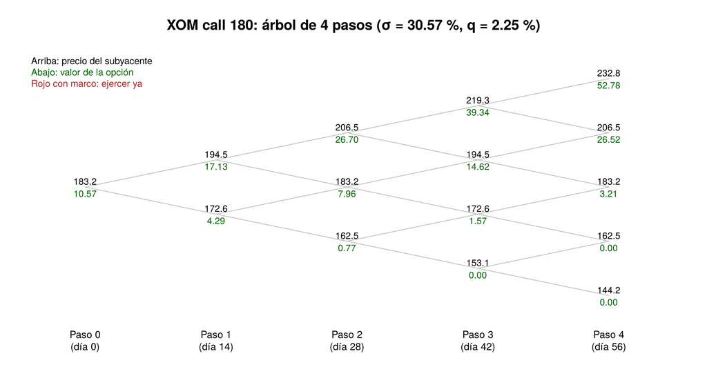

```r
dibuja.arbol("XOM call", "XOM call 180: árbol de 4 pasos (σ = 30.57 %, q = 2.25 %)")
```

```r
tabla.nodos("XOM call")
```

Nodos de los pasos 0 a 3 (y cualquier nodo de ejercicio): XOM call

| Paso | Nº de bajas | Precio S | Valor intrínseco | Valor de continuación | Valor de la opción | Decisión |
| --- | --- | --- | --- | --- | --- | --- |
| 0 | 0 | 183.21 | 3.210 | 10.569 | 10.569 | Continuar |
| 1 | 0 | 194.51 | 14.514 | 17.125 | 17.125 | Continuar |
| 1 | 1 | 172.56 | 0.000 | 4.289 | 4.289 | Continuar |
| 2 | 0 | 206.52 | 26.515 | 26.702 | 26.702 | Continuar |
| 2 | 1 | 183.21 | 3.210 | 7.958 | 7.958 | Continuar |
| 2 | 2 | 162.53 | 0.000 | 0.770 | 0.770 | Continuar |
| 3 | 0 | 219.26 | 39.257 | 39.340 | 39.340 | Continuar |
| 3 | 1 | 194.51 | 14.514 | 14.618 | 14.618 | Continuar |
| 3 | 2 | 172.56 | 0.000 | 1.572 | 1.572 | Continuar |
| 3 | 3 | 153.09 | 0.000 | 0.000 | 0.000 | Continuar |

**Conclusión.** Con 3 contrato(s) la prima pagada al ask es de 3,120 USD (3.1 % del capital). El equilibrio al vencimiento está en 190.40, un 3.9 % arriba del spot. El árbol, con la IV de TradingView (30.57 %), valúa la opción en 10.587 por acción contra un punto medio de mercado de 10.225 (el mercado cotiza 3.4 % más barato que el modelo). La prima de ejercicio anticipado es de 0.0000 USD por acción (0.00 % del valor): a 56 días es económicamente despreciable. Bajo la medida neutral al riesgo, la probabilidad de terminar en dinero es de 54 % y la de ganar neto de prima, de 36 %. El call está dentro del dinero, pero de la prima de 10.40 solo 3.21 (31 %) es valor intrínseco; el resto es valor temporal, que se perdería al ejercer. Por eso, aunque ya esté en dinero, no conviene ejercer antes: el dividendo de 2.25 % es menor que la tasa de 3.94 %. El reporte cae antes del vencimiento, así que la IV de 30.57 % incluye ese evento.

### GLD: call 366

Compra de calls con strike 366, el más cercano al spot de 366.61. GLD no paga dividendo.

```r
tabla.opcion("GLD")
```

Precios por acción y Griegas: árbol (N=500) contra TradingView

| Opción | Bid | Ask | Mid | Árbol am. | Árbol eur. | Prima EA | Delta | Delta TV | Gamma | Gamma TV | Theta | Theta TV | Vega | Vega TV | Rho | Rho TV |
| --- | --- | --- | --- | --- | --- | --- | --- | --- | --- | --- | --- | --- | --- | --- | --- | --- |
| GLD call | 13.5 | 13.8 | 13.65 | 13.234 | 13.234 | 0.0000 | 0.554 | 0.53 | 0.0134 | 0.013 | -0.125 | -0.11 | 0.568 | 0.57 | 0.293 | 0.28 |
| GLD put | 11.0 | 11.3 | 11.15 | 10.579 | 10.418 | 0.1616 | -0.455 | -0.47 | 0.0138 | 0.013 | -0.089 | -0.10 | 0.567 | 0.57 | -0.213 | -0.28 |

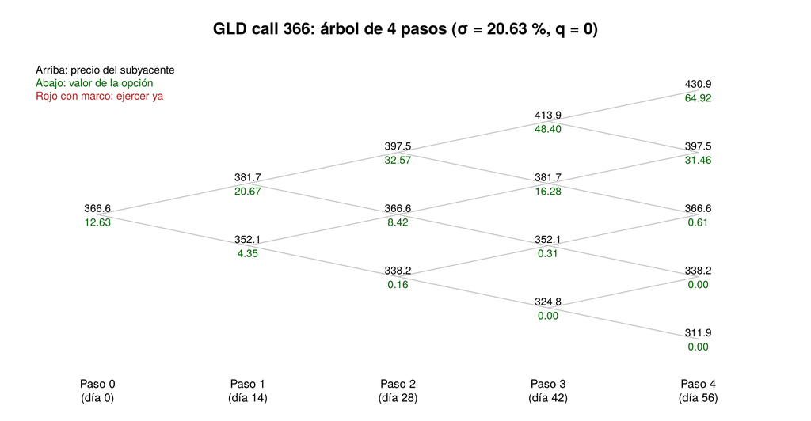

```r
dibuja.arbol("GLD call", "GLD call 366: árbol de 4 pasos (σ = 20.63 %, q = 0)")
```

```r
tabla.nodos("GLD call")
```

Nodos de los pasos 0 a 3 (y cualquier nodo de ejercicio): GLD call

| Paso | Nº de bajas | Precio S | Valor intrínseco | Valor de continuación | Valor de la opción | Decisión |
| --- | --- | --- | --- | --- | --- | --- |
| 0 | 0 | 366.61 | 0.610 | 12.633 | 12.633 | Continuar |
| 1 | 0 | 381.73 | 15.726 | 20.671 | 20.671 | Continuar |
| 1 | 1 | 352.09 | 0.000 | 4.353 | 4.353 | Continuar |
| 2 | 0 | 397.46 | 31.464 | 32.569 | 32.569 | Continuar |
| 2 | 1 | 366.61 | 0.610 | 8.419 | 8.419 | Continuar |
| 2 | 2 | 338.15 | 0.000 | 0.157 | 0.157 | Continuar |
| 3 | 0 | 413.85 | 47.852 | 48.405 | 48.405 | Continuar |
| 3 | 1 | 381.73 | 15.726 | 16.278 | 16.278 | Continuar |
| 3 | 2 | 352.09 | 0.000 | 0.310 | 0.310 | Continuar |
| 3 | 3 | 324.76 | 0.000 | 0.000 | 0.000 | Continuar |

**Conclusión.** Con 2 contrato(s) la prima pagada al ask es de 2,760 USD (2.8 % del capital). El equilibrio al vencimiento está en 379.80, un 3.6 % arriba del spot. El árbol, con la IV de TradingView (20.63 %), valúa la opción en 13.234 por acción contra un punto medio de mercado de 13.650 (el mercado cotiza 3.1 % más caro que el modelo). Como no paga dividendo, ejercer un call antes del vencimiento nunca conviene y la americana vale exactamente lo mismo que la europea. Bajo la medida neutral al riesgo, la probabilidad de terminar en dinero es de 53 % y la de ganar neto de prima, de 36 %. Es la posición de control: sin dividendo, el árbol americano y el europeo coinciden, y la tabla de nodos no marca ningún nodo de ejercicio. La liquidez es la más baja de los ETF (21 contratos de volumen en el call).

### SLV: put 48

Compra de puts con strike 48, el más cercano al spot de 48.72. SLV no paga dividendo y su IV de 37.21 % es la más alta entre los ETF.

```r
tabla.opcion("SLV")
```

Precios por acción y Griegas: árbol (N=500) contra TradingView

| Opción | Bid | Ask | Mid | Árbol am. | Árbol eur. | Prima EA | Delta | Delta TV | Gamma | Gamma TV | Theta | Theta TV | Vega | Vega TV | Rho | Rho TV |
| --- | --- | --- | --- | --- | --- | --- | --- | --- | --- | --- | --- | --- | --- | --- | --- | --- |
| SLV call | 3.3 | 3.40 | 3.350 | 3.334 | 3.334 | 0.0000 | 0.586 | 0.57 | 0.0549 | 0.055 | -0.027 | -0.026 | 0.074 | 0.075 | 0.039 | 0.038 |
| SLV put | 2.4 | 2.49 | 2.445 | 2.342 | 2.325 | 0.0171 | -0.418 | -0.43 | 0.0558 | 0.055 | -0.023 | -0.024 | 0.074 | 0.075 | -0.029 | -0.036 |

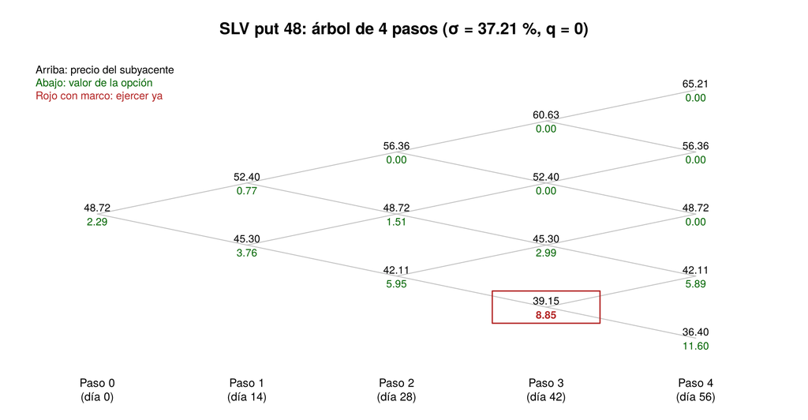

```r
dibuja.arbol("SLV put", "SLV put 48: árbol de 4 pasos (σ = 37.21 %, q = 0)")
```

```r
tabla.nodos("SLV put")
```

Nodos de los pasos 0 a 3 (y cualquier nodo de ejercicio): SLV put

| Paso | Nº de bajas | Precio S | Valor intrínseco | Valor de continuación | Valor de la opción | Decisión |
| --- | --- | --- | --- | --- | --- | --- |
| 0 | 0 | 48.72 | 0.000 | 2.285 | 2.285 | Continuar |
| 1 | 0 | 52.40 | 0.000 | 0.768 | 0.768 | Continuar |
| 1 | 1 | 45.30 | 2.704 | 3.763 | 3.763 | Continuar |
| 2 | 0 | 56.36 | 0.000 | 0.000 | 0.000 | Continuar |
| 2 | 1 | 48.72 | 0.000 | 1.514 | 1.514 | Continuar |
| 2 | 2 | 42.11 | 5.888 | 5.953 | 5.953 | Continuar |
| 3 | 0 | 60.63 | 0.000 | 0.000 | 0.000 | Continuar |
| 3 | 1 | 52.40 | 0.000 | 0.000 | 0.000 | Continuar |
| 3 | 2 | 45.30 | 2.704 | 2.986 | 2.986 | Continuar |
| 3 | 3 | 39.15 | 8.847 | 8.775 | 8.847 | EJERCER |

**Conclusión.** Con 12 contrato(s) la prima pagada al ask es de 2,988 USD (3.0 % del capital). El equilibrio al vencimiento está en 45.51, un 6.6 % abajo del spot. El árbol, con la IV de TradingView (37.21 %), valúa la opción en 2.342 por acción contra un punto medio de mercado de 2.445 (el mercado cotiza 4.4 % más caro que el modelo). La prima de ejercicio anticipado es de 0.017 USD por acción (0.73 % del valor): pequeña, pero positiva y medible. Bajo la medida neutral al riesgo, la probabilidad de terminar en dinero es de 46 % y la de ganar neto de prima, de 32 %. Con $q = 0$ el único motivo para ejercer una put antes es cobrar el strike y ponerlo a ganar intereses, de modo que la prima depende directamente de la tasa y del plazo. Aun así, la prima relativa de SLV (0.73 %) es menor que la de GLD (1.53 %) y la de SPY (1.66 %): a mayor volatilidad, más valor temporal se pierde al ejercer, y eso reduce el atractivo de hacerlo.

### NVDA: call 210

Compra de calls con strike 210, a 0.5 % por debajo del spot de 210.96. Es la cadena más líquida de las tres acciones. Su próximo reporte, según TradingView, es en 32 días, dentro de la vida de la opción.

```r
tabla.opcion("NVDA")
```

Precios por acción y Griegas: árbol (N=500) contra TradingView

| Opción | Bid | Ask | Mid | Árbol am. | Árbol eur. | Prima EA | Delta | Delta TV | Gamma | Gamma TV | Theta | Theta TV | Vega | Vega TV | Rho | Rho TV |
| --- | --- | --- | --- | --- | --- | --- | --- | --- | --- | --- | --- | --- | --- | --- | --- | --- |
| NVDA call | 14.20 | 14.35 | 14.275 | 13.918 | 13.918 | 0.0000 | 0.556 | 0.55 | 0.0122 | 0.012 | -0.124 | -0.12 | 0.326 | 0.33 | 0.159 | 0.16 |
| NVDA put | 12.05 | 12.25 | 12.150 | 11.919 | 11.845 | 0.0738 | -0.447 | -0.45 | 0.0124 | 0.012 | -0.106 | -0.11 | 0.326 | 0.33 | -0.135 | -0.17 |

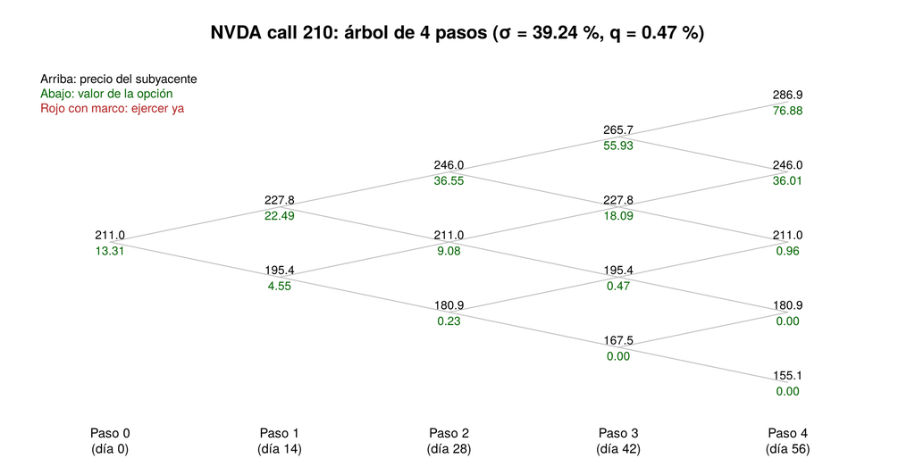

```r
dibuja.arbol("NVDA call", "NVDA call 210: árbol de 4 pasos (σ = 39.24 %, q = 0.47 %)")
```

```r
tabla.nodos("NVDA call")
```

Nodos de los pasos 0 a 3 (y cualquier nodo de ejercicio): NVDA call

| Paso | Nº de bajas | Precio S | Valor intrínseco | Valor de continuación | Valor de la opción | Decisión |
| --- | --- | --- | --- | --- | --- | --- |
| 0 | 0 | 210.96 | 0.960 | 13.314 | 13.314 | Continuar |
| 1 | 0 | 227.81 | 17.812 | 22.493 | 22.493 | Continuar |
| 1 | 1 | 195.35 | 0.000 | 4.554 | 4.554 | Continuar |
| 2 | 0 | 246.01 | 36.009 | 36.554 | 36.554 | Continuar |
| 2 | 1 | 210.96 | 0.960 | 9.079 | 9.079 | Continuar |
| 2 | 2 | 180.90 | 0.000 | 0.229 | 0.229 | Continuar |
| 3 | 0 | 265.66 | 55.661 | 55.930 | 55.930 | Continuar |
| 3 | 1 | 227.81 | 17.812 | 18.088 | 18.088 | Continuar |
| 3 | 2 | 195.35 | 0.000 | 0.469 | 0.469 | Continuar |
| 3 | 3 | 167.52 | 0.000 | 0.000 | 0.000 | Continuar |

**Conclusión.** Con 2 contrato(s) la prima pagada al ask es de 2,870 USD (2.9 % del capital). El equilibrio al vencimiento está en 224.35, un 6.3 % arriba del spot. El árbol, con la IV de TradingView (39.24 %), valúa la opción en 13.918 por acción contra un punto medio de mercado de 14.275 (el mercado cotiza 2.6 % más caro que el modelo). La prima de ejercicio anticipado es de 0.0000 USD por acción (0.00 % del valor): a 56 días es económicamente despreciable. Bajo la medida neutral al riesgo, la probabilidad de terminar en dinero es de 50 % y la de ganar neto de prima, de 33 %. El dividendo de 0.47 % es mucho menor que la tasa, así que para el call el ejercicio anticipado prácticamente no existe, y la tabla de nodos no marca ningún nodo de ejercicio.

### ASML: call 1570

Compra de calls con strike 1,570, el más cercano al spot de 1,571.80. Cada contrato controla 100 acciones de un título de casi 1,600 dólares, por eso un solo contrato ya cuesta 10,940 USD.

```r
tabla.opcion("ASML")
```

Precios por acción y Griegas: árbol (N=500) contra TradingView

| Opción | Bid | Ask | Mid | Árbol am. | Árbol eur. | Prima EA | Delta | Delta TV | Gamma | Gamma TV | Theta | Theta TV | Vega | Vega TV | Rho | Rho TV |
| --- | --- | --- | --- | --- | --- | --- | --- | --- | --- | --- | --- | --- | --- | --- | --- | --- |
| ASML call | 102.9 | 109.4 | 106.15 | 104.040 | 104.040 | 0.0000 | 0.547 | 0.54 | 0.0016 | 0.0016 | -0.952 | -0.91 | 2.435 | 2.44 | 1.164 | 1.14 |
| ASML put | 93.0 | 97.9 | 95.45 | 94.554 | 93.984 | 0.5699 | -0.456 | -0.46 | 0.0016 | 0.0016 | -0.817 | -0.86 | 2.435 | 2.44 | -1.028 | -1.26 |

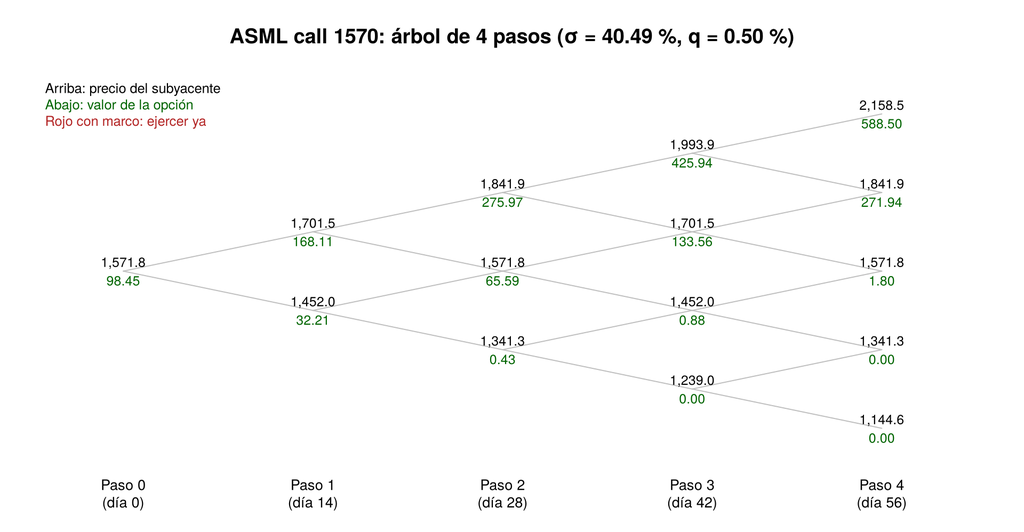

```r
dibuja.arbol("ASML call", "ASML call 1570: árbol de 4 pasos (σ = 40.49 %, q = 0.50 %)")
```

```r
tabla.nodos("ASML call")
```

Nodos de los pasos 0 a 3 (y cualquier nodo de ejercicio): ASML call

| Paso | Nº de bajas | Precio S | Valor intrínseco | Valor de continuación | Valor de la opción | Decisión |
| --- | --- | --- | --- | --- | --- | --- |
| 0 | 0 | 1,571.80 | 1.800 | 98.450 | 98.450 | Continuar |
| 1 | 0 | 1,701.52 | 131.517 | 168.109 | 168.109 | Continuar |
| 1 | 1 | 1,451.97 | 0.000 | 32.214 | 32.214 | Continuar |
| 2 | 0 | 1,841.94 | 271.939 | 275.970 | 275.970 | Continuar |
| 2 | 1 | 1,571.80 | 1.800 | 65.595 | 65.595 | Continuar |
| 2 | 2 | 1,341.28 | 0.000 | 0.428 | 0.428 | Continuar |
| 3 | 0 | 1,993.95 | 423.949 | 425.938 | 425.938 | Continuar |
| 3 | 1 | 1,701.52 | 131.517 | 133.561 | 133.561 | Continuar |
| 3 | 2 | 1,451.97 | 0.000 | 0.878 | 0.878 | Continuar |
| 3 | 3 | 1,239.03 | 0.000 | 0.000 | 0.000 | Continuar |

### AMD: put 510

Compra de puts con strike 510, a 1.3 % por debajo del spot de 516.79 (queda fuera del dinero). AMD no paga dividendo y tiene la IV más alta del portafolio, de 55.17 %.

```r
tabla.opcion("AMD")
```

Precios por acción y Griegas: árbol (N=500) contra TradingView

| Opción | Bid | Ask | Mid | Árbol am. | Árbol eur. | Prima EA | Delta | Delta TV | Gamma | Gamma TV | Theta | Theta TV | Vega | Vega TV | Rho | Rho TV |
| --- | --- | --- | --- | --- | --- | --- | --- | --- | --- | --- | --- | --- | --- | --- | --- | --- |
| AMD call | 49.65 | 51.85 | 50.750 | 49.164 | 49.164 | 0.0000 | 0.578 | 0.57 | 0.0035 | 0.0035 | -0.417 | -0.40 | 0.793 | 0.79 | 0.384 | 0.38 |
| AMD put | 40.10 | 41.05 | 40.575 | 39.489 | 39.300 | 0.1891 | -0.425 | -0.43 | 0.0035 | 0.0035 | -0.367 | -0.38 | 0.793 | 0.79 | -0.334 | -0.40 |

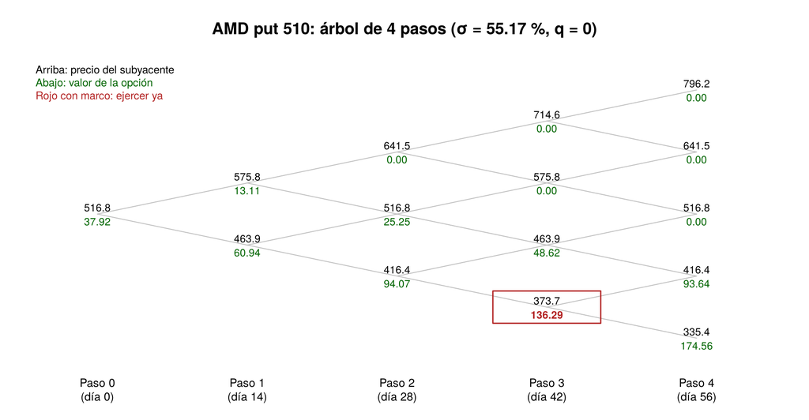

```r
dibuja.arbol("AMD put", "AMD put 510: árbol de 4 pasos (σ = 55.17 %, q = 0)")
```

```r
tabla.nodos("AMD put")
```

Nodos de los pasos 0 a 3 (y cualquier nodo de ejercicio): AMD put

| Paso | Nº de bajas | Precio S | Valor intrínseco | Valor de continuación | Valor de la opción | Decisión |
| --- | --- | --- | --- | --- | --- | --- |
| 0 | 0 | 516.79 | 0.000 | 37.923 | 37.923 | Continuar |
| 1 | 0 | 575.76 | 0.000 | 13.108 | 13.108 | Continuar |
| 1 | 1 | 463.86 | 46.138 | 60.940 | 60.940 | Continuar |
| 2 | 0 | 641.45 | 0.000 | 0.000 | 0.000 | Continuar |
| 2 | 1 | 516.79 | 0.000 | 25.245 | 25.245 | Continuar |
| 2 | 2 | 416.36 | 93.645 | 94.065 | 94.065 | Continuar |
| 3 | 0 | 714.64 | 0.000 | 0.000 | 0.000 | Continuar |
| 3 | 1 | 575.76 | 0.000 | 0.000 | 0.000 | Continuar |
| 3 | 2 | 463.86 | 46.138 | 48.622 | 48.622 | Continuar |
| 3 | 3 | 373.71 | 136.286 | 135.516 | 136.286 | EJERCER |

**Conclusión.** Con 1 contrato(s) la prima pagada al ask es de 4,105 USD (4.1 % del capital). El equilibrio al vencimiento está en 468.95, un 9.3 % abajo del spot. El árbol, con la IV de TradingView (55.17 %), valúa la opción en 39.489 por acción contra un punto medio de mercado de 40.575 (el mercado cotiza 2.7 % más caro que el modelo). La prima de ejercicio anticipado es de 0.1891 USD por acción (0.48 % del valor): a 56 días es económicamente despreciable. Bajo la medida neutral al riesgo, la probabilidad de terminar en dinero es de 51 % y la de ganar neto de prima, de 34 %. Es la put con mayor volatilidad del lote, así que toda su prima es valor temporal (el spot está arriba del strike), que se perdería al ejercer. En el árbol de 4 pasos hay nodos de ejercicio solo en los caminos de varias bajas seguidas.

**Reporte de AMD.** La ficha de TradingView del 24-oct-2026 marca el próximo reporte en 10 días (alrededor del 3 de noviembre), dentro de la vida de la opción. La IV de 55.17 % incluye ese evento, lo que explica que sea la más alta del lote; después del reporte esa volatilidad suele bajar, y la put perdería valor por vega aunque el precio se moviera a favor. La misma ficha muestra que AMD no paga dividendo, lo que confirma q = 0.

## Forecast: qué dice el árbol sobre el precio a vencimiento

El árbol de 500 pasos define una distribución del precio a vencimiento, que es una binomial con la probabilidad neutral $p$. Con ella se calculan los percentiles, la probabilidad de terminar en dinero y la de ganar neto de prima. Son probabilidades **neutrales al riesgo**: el precio crece a $r - q$ y no incorpora ninguna opinión direccional.

```r
fc <- do.call(rbind, lapply(seq_len(nrow(pos)), function(i) {
  p <- pos[i, ]; x <- M[p$id, ]
  dist <- distribucion.terminal(x$S, rf, x$q, x$iv_tv / 100, T_anios, N_precio)
  dist <- dist[order(dist$S), ]
  cum  <- cumsum(dist$prob)
  qs   <- sapply(c(0.05, 0.25, 0.5, 0.75, 0.95), function(a) dist$S[which(cum >= a)[1]])
  pago <- if (x$tipo == "call") pmax(dist$S - x$K, 0) else pmax(x$K - dist$S, 0)
  data.frame(Activo = p$activo, Posicion = paste(p$tipo, p$K),
             Esperado = sum(dist$S * dist$prob), P5 = qs[1], P25 = qs[2], P50 = qs[3],
             P75 = qs[4], P95 = qs[5],
             ITM = sum(dist$prob[pago > 0]) * 100,
             Ganar = sum(dist$prob[pago > p$ask]) * 100,
             PagoEsp = sum(pago * dist$prob),
             Prima = p$ask)
}))
kable(fc, digits = c(0, 0, 2, 2, 2, 2, 2, 2, 1, 1, 2, 2), row.names = FALSE,
      format.args = list(big.mark = ","),
      col.names = c("Activo", "Posición", "S esperado", "P5", "P25", "Mediana", "P75",
                    "P95", "Prob. en dinero (%)", "Prob. de ganar neto (%)",
                    "Pago esperado", "Prima (ask)"),
      caption = "Distribución del precio a vencimiento implícita en el árbol (N=500, 18-dic-2026)") %>%
  kable_styling(bootstrap_options = c("striped", "hover", "condensed"),
                full_width = FALSE, font_size = 12)
```

Distribución del precio a vencimiento implícita en el árbol (N=500, 18-dic-2026)

| Activo | Posición | S esperado | P5 | P25 | Mediana | P75 | P95 | Prob. en dinero (%) | Prob. de ganar neto (%) | Pago esperado | Prima (ask) |
| --- | --- | --- | --- | --- | --- | --- | --- | --- | --- | --- | --- |
| SPY | put 759 | 763.41 | 693.43 | 733.37 | 763.85 | 791.56 | 837.15 | 46.2 | 32.5 | 15.17 | 16.24 |
| TLT | call 81 | 81.32 | 73.11 | 77.77 | 81.34 | 84.60 | 89.99 | 50.4 | 36.4 | 2.20 | 1.82 |
| XOM | call 180 | 183.69 | 149.48 | 168.17 | 183.21 | 197.47 | 222.16 | 53.8 | 36.3 | 10.65 | 10.40 |
| GLD | call 366 | 368.83 | 321.89 | 348.52 | 366.61 | 388.43 | 420.57 | 53.2 | 35.6 | 13.31 | 13.80 |
| SLV | put 48 | 49.02 | 38.03 | 43.89 | 48.72 | 53.38 | 61.60 | 45.9 | 32.3 | 2.34 | 2.49 |
| NVDA | call 210 | 212.09 | 162.47 | 188.99 | 210.96 | 232.27 | 270.19 | 50.1 | 32.8 | 14.00 | 14.35 |
| ASML | call 1570 | 1,580.12 | 1,200.45 | 1,403.18 | 1,549.66 | 1,735.89 | 2,029.03 | 49.9 | 32.7 | 104.67 | 109.40 |
| AMD | put 510 | 519.92 | 357.95 | 442.75 | 506.90 | 591.66 | 717.82 | 51.4 | 34.0 | 39.54 | 41.05 |

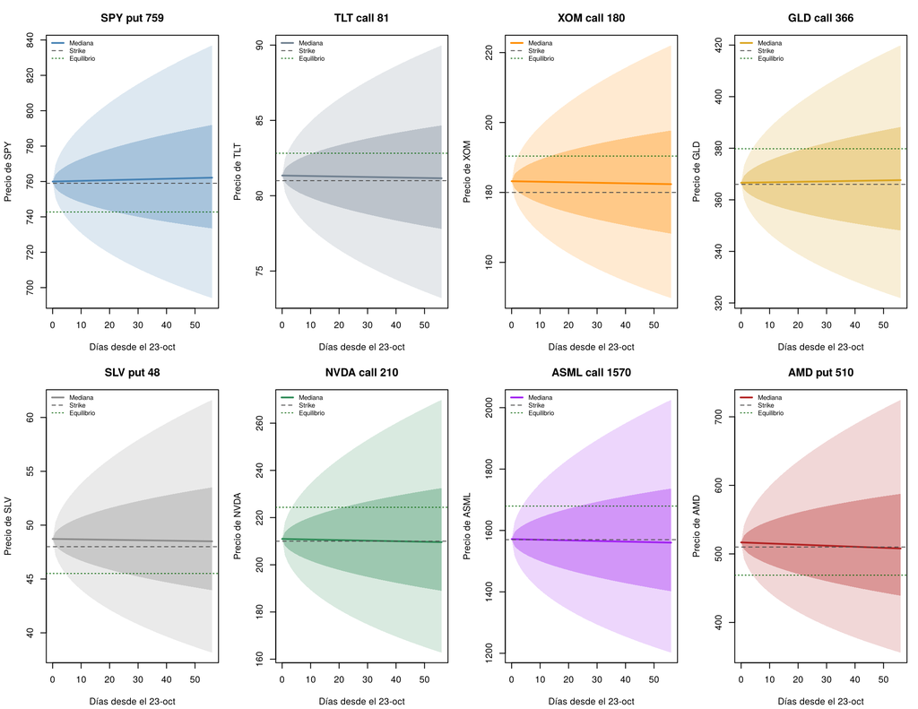

```r
par(mfrow = c(2, 4), mar = c(4.2, 4.2, 3.2, 1))
pasos <- 0:56
for (a in activos) {
  p <- pos[a, ]; x <- M[p$id, ]; s <- x$iv_tv / 100
  qf <- function(al) sapply(pasos, function(i) cuantil.arbol(x$S, rf, x$q, s, i, al))
  q05 <- qf(0.05); q25 <- qf(0.25); q50 <- qf(0.5); q75 <- qf(0.75); q95 <- qf(0.95)
  plot(pasos, q50, type = "n", ylim = range(c(q05, q95, p$equilibrio, p$K)),
       xlab = "Días desde el 23-oct", ylab = paste("Precio de", a),
       main = paste(a, p$tipo, p$K))
  polygon(c(pasos, rev(pasos)), c(q05, rev(q95)), col = adjustcolor(colores[a], 0.18), border = NA)
  polygon(c(pasos, rev(pasos)), c(q25, rev(q75)), col = adjustcolor(colores[a], 0.35), border = NA)
  lines(pasos, q50, col = colores[a], lwd = 2)
  abline(h = p$K, col = "gray30", lty = 2); abline(h = p$equilibrio, col = "darkgreen", lty = 3)
  legend("topleft", bty = "n", cex = 0.7, lty = c(1, 2, 3), lwd = c(2, 1, 1),
         col = c(colores[a], "gray30", "darkgreen"), legend = c("Mediana", "Strike", "Equilibrio"))
}
```

```r
par(mfrow = c(1, 1))
```

**Interpretación.** Las bandas son los percentiles 5-95 (claro) y 25-75 (oscuro) del precio que implica el árbol (en su límite continuo) día a día; se ensanchan con la raíz del tiempo y son más anchas donde la volatilidad es mayor (AMD, ASML, NVDA, SLV frente a SPY y TLT). La línea del equilibrio dice cuánto tiene que moverse el precio para que la posición gane: en TLT, SPY, GLD es el movimiento más pequeño y en AMD, ASML, SLV, el más grande. Una probabilidad de ganar neto de prima de entre 32 % y 36 % es lo normal para opciones cerca del dinero: se paga prima, y para recuperarla hace falta que el precio termine más allá del strike.